# Modelowanie ryzyka kredytowego: PD, LGD, EAD i Expected Loss

## Cel projektu

Celem projektu jest zbudowanie kompletnego pipeline'u do oceny ryzyka kredytowego dla portfela pożyczek.

Projekt obejmuje:

1. eksplorację i przygotowanie danych,
2. definicję defaultu,
3. modelowanie **PD** (*Probability of Default*),
4. kalibrację prawdopodobieństw PD,
5. modelowanie **LGD** (*Loss Given Default*),
6. przyjęcie i uzasadnienie **EAD** (*Exposure at Default*),
7. wyznaczenie **Expected Loss**,
8. analizę portfela,
9. symulację polityki odrzucania najbardziej ryzykownych kredytów,
10. wnioski biznesowe.

## 0. Import bibliotek

Notebook wykorzystuje głównie `pandas`, `numpy`, `scikit-learn`, `xgboost` i `lightgbm`.

```python
import warnings

import numpy as np
import pandas as pd
import matplotlib.pyplot as plt

from sklearn.compose import ColumnTransformer
from sklearn.model_selection import train_test_split
from sklearn.pipeline import Pipeline

from sklearn.impute import SimpleImputer
from sklearn.preprocessing import OneHotEncoder, StandardScaler

from sklearn.linear_model import LogisticRegression, LinearRegression, Ridge
from sklearn.ensemble import (
    GradientBoostingClassifier,
    GradientBoostingRegressor,
    RandomForestClassifier,
    RandomForestRegressor,
)

from sklearn.metrics import (
    accuracy_score,
    brier_score_loss,
    classification_report,
    confusion_matrix,
    f1_score,
    mean_absolute_error,
    mean_squared_error,
    precision_score,
    r2_score,
    recall_score,
    roc_auc_score,
    roc_curve,
)

from sklearn.calibration import calibration_curve

from xgboost import XGBClassifier, XGBRegressor
from lightgbm import LGBMClassifier, LGBMRegressor


warnings.filterwarnings("ignore")

RANDOM_STATE = 42

pd.set_option("display.max_columns", 200)
pd.set_option("display.float_format", lambda x: f"{x:,.4f}")
```

## 1. Wczytanie danych

```python
SCIEZKA_DANYCH = "loan.csv"
dane = pd.read_csv(SCIEZKA_DANYCH, low_memory=False)
print("Rozmiar danych:", dane.shape)
display(dane.head())
```

```
Rozmiar danych: (2260668, 145)
```

|  | id | member_id | loan_amnt | funded_amnt | funded_amnt_inv | term | int_rate | installment | grade | sub_grade | emp_title | emp_length | home_ownership | annual_inc | verification_status | issue_d | loan_status | pymnt_plan | url | desc | purpose | title | zip_code | addr_state | dti | delinq_2yrs | earliest_cr_line | inq_last_6mths | mths_since_last_delinq | … |
| --- | --- | --- | --- | --- | --- | --- | --- | --- | --- | --- | --- | --- | --- | --- | --- | --- | --- | --- | --- | --- | --- | --- | --- | --- | --- | --- | --- | --- | --- | --- |
| 0 | NaN | NaN | 2500 | 2500 | 2,500.0000 | 36 months | 13.5600 | 84.9200 | C | C1 | Chef | 10+ years | RENT | 55,000.0000 | Not Verified | Dec-2018 | Current | n | NaN | NaN | debt_consolidation | Debt consolidation | 109xx | NY | 18.2400 | 0.0000 | Apr-2001 | 1.0000 | NaN | … |
| 1 | NaN | NaN | 30000 | 30000 | 30,000.0000 | 60 months | 18.9400 | 777.2300 | D | D2 | Postmaster | 10+ years | MORTGAGE | 90,000.0000 | Source Verified | Dec-2018 | Current | n | NaN | NaN | debt_consolidation | Debt consolidation | 713xx | LA | 26.5200 | 0.0000 | Jun-1987 | 0.0000 | 71.0000 | … |
| 2 | NaN | NaN | 5000 | 5000 | 5,000.0000 | 36 months | 17.9700 | 180.6900 | D | D1 | Administrative | 6 years | MORTGAGE | 59,280.0000 | Source Verified | Dec-2018 | Current | n | NaN | NaN | debt_consolidation | Debt consolidation | 490xx | MI | 10.5100 | 0.0000 | Apr-2011 | 0.0000 | NaN | … |
| 3 | NaN | NaN | 4000 | 4000 | 4,000.0000 | 36 months | 18.9400 | 146.5100 | D | D2 | IT Supervisor | 10+ years | MORTGAGE | 92,000.0000 | Source Verified | Dec-2018 | Current | n | NaN | NaN | debt_consolidation | Debt consolidation | 985xx | WA | 16.7400 | 0.0000 | Feb-2006 | 0.0000 | NaN | … |
| 4 | NaN | NaN | 30000 | 30000 | 30,000.0000 | 60 months | 16.1400 | 731.7800 | C | C4 | Mechanic | 10+ years | MORTGAGE | 57,250.0000 | Not Verified | Dec-2018 | Current | n | NaN | NaN | debt_consolidation | Debt consolidation | 212xx | MD | 26.3500 | 0.0000 | Dec-2000 | 0.0000 | NaN | … |

## 2. Wstępna eksploracja danych

Sprawdzam strukturę danych, typy zmiennych, braki danych oraz podstawowe statystyki.

W tym kroku:

- zamieniam procenty na wartości liczbowe,
- zamieniam okres kredytu na liczbę miesięcy,
- tworzę długość historii kredytowej,
- tworzę wskaźniki relatywne, np. rata do dochodu i kwota kredytu do dochodu.

Takie zmienne często są bardziej informacyjne niż same wartości nominalne.

```python
def oczysc_kolumne_procentowa(series):
    """
    Funkcja usuwa znak procentu z kolumny tekstowej i zamienia wartości na liczby.
    Dzięki temu zmienne takie jak oprocentowanie lub wykorzystanie limitu mogą być
    użyte w analizie i modelowaniu.
    """
    return (
        series.astype(str)
        .str.replace("%", "", regex=False)
        .str.replace("nan", "", regex=False)
        .replace("", np.nan)
        .astype(float)
    )


def oczysc_okres_kredytu(series):
    """
    Funkcja wyciąga liczbę miesięcy z kolumny opisującej okres kredytu.
    Przykładowo wartość '36 months' zostaje zamieniona na 36.
    """
    return (
        series.astype(str)
        .str.extract(r"(\d+)")[0]
        .astype(float)
    )


def oblicz_miesiace_od_daty(series):
    """
    Funkcja zamienia datę pierwszej linii kredytowej na liczbę miesięcy historii kredytowej.
    Jako punkt odniesienia przyjmuje najnowszą datę występującą w kolumnie.
    """
    dates = pd.to_datetime(series, errors="coerce")
    data_odniesienia = dates.max()

    miesiace = (data_odniesienia.year - dates.dt.year) * 12 + (
        data_odniesienia.month - dates.dt.month
    )

    return miesiace


dane_model = dane.copy()

dane_model["int_rate"] = oczysc_kolumne_procentowa(dane_model["int_rate"])
dane_model["revol_util"] = oczysc_kolumne_procentowa(dane_model["revol_util"])
dane_model["term_months"] = oczysc_okres_kredytu(dane_model["term"])

dane_model["credit_history_months"] = oblicz_miesiace_od_daty(
    dane_model["earliest_cr_line"]
)

dane_model["installment_to_income"] = (
    dane_model["installment"] / dane_model["annual_inc"].replace(0, np.nan)
)

dane_model["loan_to_income"] = (
    dane_model["loan_amnt"] / dane_model["annual_inc"].replace(0, np.nan)
)

dane_model["funded_to_income"] = (
    dane_model["funded_amnt"] / dane_model["annual_inc"].replace(0, np.nan)
)

dane_model["revol_bal_to_income"] = (
    dane_model["revol_bal"] / dane_model["annual_inc"].replace(0, np.nan)
)


zmienne_objasniajace = [
    "loan_amnt",
    "funded_amnt",
    "term_months",
    "int_rate",
    "installment",
    "grade",
    "sub_grade",
    "emp_length",
    "home_ownership",
    "annual_inc",
    "verification_status",
    "purpose",
    "dti",
    "delinq_2yrs",
    "inq_last_6mths",
    "open_acc",
    "pub_rec",
    "revol_bal",
    "revol_util",
    "total_acc",
    "credit_history_months",
    "installment_to_income",
    "loan_to_income",
    "funded_to_income",
    "revol_bal_to_income"
]

dane_model = dane_model[zmienne_objasniajace + ["loan_status"]].copy()
```

```python
print("Informacje o zmiennych objaśniających:")
display(dane_model[zmienne_objasniajace].info())

print("\nUdział braków danych w zmiennych objaśniających:")
display(
    dane_model[zmienne_objasniajace]
    .isna()
    .mean()
    .sort_values(ascending=False)
)

liczba_wierszy_przed = dane_model.shape[0]

dane_model = dane_model.dropna(subset=zmienne_objasniajace).copy()

liczba_wierszy_po = dane_model.shape[0]
liczba_usunietych_wierszy = liczba_wierszy_przed - liczba_wierszy_po

print("Liczba wierszy przed usunięciem braków danych:", liczba_wierszy_przed)
print("Liczba wierszy po usunięciu braków danych:", liczba_wierszy_po)
print("Liczba usuniętych wierszy:", liczba_usunietych_wierszy)

print("\nUdział braków danych po czyszczeniu:")
display(
    dane_model[zmienne_objasniajace]
    .isna()
    .mean()
    .sort_values(ascending=False)
)

zmienne_numeryczne = dane_model[zmienne_objasniajace].select_dtypes(include=["number"]).columns
zmienne_kategoryczne = dane_model[zmienne_objasniajace].select_dtypes(exclude=["number"]).columns

print("\nPodstawowe statystyki zmiennych numerycznych:")
display(dane_model[zmienne_numeryczne].describe().T)

print("\nPodstawowe statystyki zmiennych kategorycznych:")
display(dane_model[zmienne_kategoryczne].describe().T)
```

```
Informacje o zmiennych objaśniających:
<class 'pandas.core.frame.DataFrame'>
RangeIndex: 2260668 entries, 0 to 2260667
Data columns (total 25 columns):
 #   Column                 Dtype
---  ------                 -----
 0   loan_amnt              int64
 1   funded_amnt            int64
 2   term_months            float64
 3   int_rate               float64
 4   installment            float64
 5   grade                  object
 6   sub_grade              object
 7   emp_length             object
 8   home_ownership         object
```

[output cut: 18 more lines]

```
None
```

```
Udział braków danych w zmiennych objaśniających:
```

```
emp_length              0.0650
revol_util              0.0008
dti                     0.0008
funded_to_income        0.0007
loan_to_income          0.0007
installment_to_income   0.0007
revol_bal_to_income     0.0007
inq_last_6mths          0.0000
pub_rec                 0.0000
delinq_2yrs             0.0000
open_acc                0.0000
credit_history_months   0.0000
total_acc               0.0000
annual_inc              0.0000
grade                   0.0000
term_months             0.0000
int_rate                0.0000
installment             0.0000
sub_grade               0.0000
revol_bal               0.0000
home_ownership          0.0000
funded_amnt             0.0000
purpose                 0.0000
verification_status     0.0000
loan_amnt               0.0000
dtype: float64
```

```
Liczba wierszy przed usunięciem braków danych: 2260668
Liczba wierszy po usunięciu braków danych: 2111995
Liczba usuniętych wierszy: 148673

Udział braków danych po czyszczeniu:
```

```
loan_amnt               0.0000
delinq_2yrs             0.0000
funded_to_income        0.0000
loan_to_income          0.0000
installment_to_income   0.0000
credit_history_months   0.0000
total_acc               0.0000
revol_util              0.0000
revol_bal               0.0000
pub_rec                 0.0000
open_acc                0.0000
inq_last_6mths          0.0000
dti                     0.0000
funded_amnt             0.0000
purpose                 0.0000
verification_status     0.0000
annual_inc              0.0000
home_ownership          0.0000
emp_length              0.0000
sub_grade               0.0000
grade                   0.0000
installment             0.0000
int_rate                0.0000
term_months             0.0000
revol_bal_to_income     0.0000
dtype: float64
```

```
Podstawowe statystyki zmiennych numerycznych:
```

|  | count | mean | std | min | 25% | 50% | 75% | max |
| --- | --- | --- | --- | --- | --- | --- | --- | --- |
| loan_amnt | 2,111,995.0000 | 15,252.0815 | 9,219.8930 | 500.0000 | 8,000.0000 | 13,125.0000 | 20,000.0000 | 40,000.0000 |
| funded_amnt | 2,111,995.0000 | 15,246.5439 | 9,218.0940 | 500.0000 | 8,000.0000 | 13,075.0000 | 20,000.0000 | 40,000.0000 |
| term_months | 2,111,995.0000 | 43.0446 | 10.9291 | 36.0000 | 36.0000 | 36.0000 | 60.0000 | 60.0000 |
| int_rate | 2,111,995.0000 | 13.0845 | 4.8281 | 5.3100 | 9.4900 | 12.6200 | 15.9900 | 30.9900 |
| installment | 2,111,995.0000 | 451.1929 | 268.0854 | 4.9300 | 256.5600 | 384.0600 | 600.7800 | 1,719.8300 |
| annual_inc | 2,111,995.0000 | 79,955.8770 | 115,183.9294 | 20.0000 | 48,000.0000 | 67,000.0000 | 95,000.0000 | 110,000,000.0000 |
| dti | 2,111,995.0000 | 18.5856 | 11.7916 | -1.0000 | 11.8600 | 17.7400 | 24.3200 | 999.0000 |
| delinq_2yrs | 2,111,995.0000 | 0.3111 | 0.8739 | 0.0000 | 0.0000 | 0.0000 | 0.0000 | 58.0000 |
| inq_last_6mths | 2,111,995.0000 | 0.5801 | 0.8893 | 0.0000 | 0.0000 | 0.0000 | 1.0000 | 33.0000 |
| open_acc | 2,111,995.0000 | 11.7132 | 5.6560 | 1.0000 | 8.0000 | 11.0000 | 15.0000 | 101.0000 |
| pub_rec | 2,111,995.0000 | 0.1924 | 0.5679 | 0.0000 | 0.0000 | 0.0000 | 0.0000 | 86.0000 |
| revol_bal | 2,111,995.0000 | 16,901.2441 | 23,161.3005 | 0.0000 | 6,080.0000 | 11,518.0000 | 20,530.0000 | 2,904,836.0000 |
| revol_util | 2,111,995.0000 | 50.6433 | 24.6586 | 0.0000 | 31.9000 | 50.7000 | 69.6000 | 892.3000 |
| total_acc | 2,111,995.0000 | 24.2884 | 12.0051 | 1.0000 | 16.0000 | 22.0000 | 31.0000 | 176.0000 |
| credit_history_months | 2,111,995.0000 | 187.1321 | 90.5651 | 0.0000 | 125.0000 | 172.0000 | 236.0000 | 992.0000 |
| installment_to_income | 2,111,995.0000 | 0.0067 | 0.0433 | 0.0000 | 0.0038 | 0.0059 | 0.0086 | 40.2772 |
| loan_to_income | 2,111,995.0000 | 0.2242 | 1.3894 | 0.0002 | 0.1244 | 0.2000 | 0.2927 | 1,200.0000 |
| funded_to_income | 2,111,995.0000 | 0.2242 | 1.3894 | 0.0002 | 0.1244 | 0.2000 | 0.2927 | 1,200.0000 |
| revol_bal_to_income | 2,111,995.0000 | 0.2263 | 0.9093 | 0.0000 | 0.0965 | 0.1770 | 0.2918 | 936.6970 |

```
Podstawowe statystyki zmiennych kategorycznych:
```

|  | count | unique | top | freq |
| --- | --- | --- | --- | --- |
| grade | 2111995 | 7 | B | 619968 |
| sub_grade | 2111995 | 35 | C1 | 136132 |
| emp_length | 2111995 | 11 | 10+ years | 747409 |
| home_ownership | 2111995 | 6 | MORTGAGE | 1044515 |
| verification_status | 2111995 | 3 | Source Verified | 857902 |
| purpose | 2111995 | 14 | debt_consolidation | 1197692 |

## 3. Definicja defaultu

W modelowaniu ryzyka kredytowego najpierw trzeba zdefiniować, które kredyty uznajemy za default.

W danych Lending Club typowe statusy defaultowe to m.in.:

- `Charged Off`,
- `Default`,

Za dobre kredyty przyjmuję statusy zakończone pełną spłatą, np. `Fully Paid`.

Kredyty aktywne lub niejednoznaczne usuwam z modelowania, ponieważ nie znamy jeszcze ich finalnego wyniku.

```python
statusy_default = [
    "Charged Off",
    "Default",
    "Does not meet the credit policy. Status:Charged Off"
]

statusy_dobre = [
    "Fully Paid",
    "Does not meet the credit policy. Status:Fully Paid"
]

dane_model = dane_model[
    dane_model["loan_status"].isin(statusy_default + statusy_dobre)
].copy()

dane_model["czy_default"] = np.where(
    dane_model["loan_status"].isin(statusy_default),
    1,
    0
)

print("Rozmiar danych po wyborze zakończonego kredytu:", dane_model.shape)

print("\nRozkład zmiennej czy_default:")
display(dane_model["czy_default"].value_counts())

print("\nUdział defaultu:")
display(dane_model["czy_default"].value_counts(normalize=True))
```

```
Rozmiar danych po wyborze zakończonego kredytu: (1230079, 27)

Rozkład zmiennej czy_default:
```

```
czy_default
0    988206
1    241873
Name: count, dtype: int64
```

```
Udział defaultu:
```

```
czy_default
0   0.8034
1   0.1966
Name: proportion, dtype: float64
```

## 5. Wybór zmiennych do modeli

Wybieram zmienne, które mogą mieć wpływ na ryzyko kredytowe.

Celowo nie używam zmiennych, które bezpośrednio zdradzałyby przyszły wynik kredytu, np. `recoveries`, `collection_recovery_fee`, `total_pymnt`, ponieważ prowadziłoby to do przecieku informacji.

```python
X = dane_model[zmienne_objasniajace].copy()
y = dane_model["czy_default"].copy()

zmienne_numeryczne = X.select_dtypes(include=["number"]).columns.tolist()
zmienne_kategoryczne = X.select_dtypes(include=["object", "category", "bool"]).columns.tolist()

print("Liczba zmiennych objaśniających:", len(zmienne_objasniajace))

print("\nZmienne objaśniające użyte w modelu:")
print(zmienne_objasniajace)

print("\nZmienne numeryczne:")
print(zmienne_numeryczne)

print("\nZmienne kategoryczne:")
print(zmienne_kategoryczne)
```

```
Liczba zmiennych objaśniających: 25

Zmienne objaśniające użyte w modelu:
['loan_amnt', 'funded_amnt', 'term_months', 'int_rate', 'installment', 'grade', 'sub_grade', 'emp_length', 'home_ownership', 'annual_inc', 'verification_status', 'purpose', 'dti', 'delinq_2yrs', 'inq_last_6mths', 'open_acc', 'pub_rec', 'revol_bal', 'revol_util', 'total_acc', 'credit_history_months',…

Zmienne numeryczne:
['loan_amnt', 'funded_amnt', 'term_months', 'int_rate', 'installment', 'annual_inc', 'dti', 'delinq_2yrs', 'inq_last_6mths', 'open_acc', 'pub_rec', 'revol_bal', 'revol_util', 'total_acc', 'credit_history_months', 'installment_to_income', 'loan_to_income', 'funded_to_income', 'revol_bal_to_income']

Zmienne kategoryczne:
['grade', 'sub_grade', 'emp_length', 'home_ownership', 'verification_status', 'purpose']
```

## 6. Podział na zbiór treningowy i testowy

Stosuję podział warstwowy (`stratify=y`), żeby udział defaultów był podobny w zbiorze treningowym i testowym.

```python
X_train, X_test, y_train, y_test = train_test_split(
    X,
    y,
    test_size=0.25,
    random_state=RANDOM_STATE,
    stratify=y
)

print("Rozmiar zbioru treningowego:", X_train.shape)
print("Rozmiar zbioru testowego:", X_test.shape)
print("Udział defaultu w zbiorze treningowym:", y_train.mean())
print("Udział defaultu w zbiorze testowym:", y_test.mean())
```

```
Rozmiar zbioru treningowego: (922559, 25)
Rozmiar zbioru testowego: (307520, 25)
Udział defaultu w zbiorze treningowym: 0.19663241050165897
Udział defaultu w zbiorze testowym: 0.19663111342351716
```

## 7. Preprocessing

Dla modeli liniowych standaryzuję zmienne numeryczne.

Dla modeli drzewiastych standaryzacja nie jest konieczna, dlatego stosuję osobny pipeline.

Dla zmiennych kategorycznych używam kodowania One-Hot.

```python
preprocessing_drzewo = ColumnTransformer(
    transformers=[
        ("numeryczne", SimpleImputer(strategy="median"), zmienne_numeryczne),
        ("kategoryczne", Pipeline(steps=[
            ("uzupelnienie", SimpleImputer(strategy="most_frequent")),
            ("kodowanie", OneHotEncoder(handle_unknown="ignore"))
        ]), zmienne_kategoryczne)
    ]
)


preprocessing_liniowy = ColumnTransformer(
    transformers=[
        ("numeryczne", Pipeline(steps=[
            ("uzupelnienie", SimpleImputer(strategy="median")),
            ("skalowanie", StandardScaler())
        ]), zmienne_numeryczne),
        ("kategoryczne", Pipeline(steps=[
            ("uzupelnienie", SimpleImputer(strategy="most_frequent")),
            ("kodowanie", OneHotEncoder(handle_unknown="ignore"))
        ]), zmienne_kategoryczne)
    ]
)
```

# Część A: Modelowanie PD

**PD** oznacza prawdopodobieństwo defaultu.

W tej części porównuję kilka modeli klasyfikacyjnych:

- Logistic Regression,
- Random Forest,
- Gradient Boosting,
- XGBoost,
- LightGBM.

Modele oceniam za pomocą:

- AUC (zdolność modelu do odróżniania klientów dobrych od złych),
- Gini (siła dyskryminacyjna modelu; przekształcenie AUC),
- Brier Score (jakość prognozowanych prawdopodobieństw),
- Accuracy (odsetek poprawnych klasyfikacji),
- Precision (ile wskazanych defaultów faktycznie było defaultami),
- Recall (ile rzeczywistych defaultów model wykrył),
- F1 (równowaga między precision i recall).

```python
def ocen_model(nazwa_modelu, model, X_test, y_test):
    """
    Funkcja ocenia model klasyfikacyjny.
    Wyznacza predykcję klasy, prawdopodobieństwo defaultu oraz podstawowe miary jakości.
    """
    y_pred = model.predict(X_test)
    y_prob = model.predict_proba(X_test)[:, 1]

    wyniki = {
        "model": nazwa_modelu,
        "auc": roc_auc_score(y_test, y_prob),
        "gini": 2 * roc_auc_score(y_test, y_prob) - 1,
        "accuracy": accuracy_score(y_test, y_pred),
        "precision": precision_score(y_test, y_pred),
        "recall": recall_score(y_test, y_pred),
        "f1": f1_score(y_test, y_pred)
    }

    print("=" * 60)
    print(nazwa_modelu)
    print("=" * 60)
    print("AUC:", round(wyniki["auc"], 4))
    print("Gini:", round(wyniki["gini"], 4))

    print("\nMacierz pomyłek:")
    print(confusion_matrix(y_test, y_pred))

    print("\nRaport klasyfikacji:")
    print(classification_report(y_test, y_pred))

    return wyniki


modele_pd = {
    "Logistic Regression": Pipeline(steps=[
        ("preprocessing", preprocessing_liniowy),
        ("model", LogisticRegression(
            max_iter=1000,
            random_state=RANDOM_STATE
        ))
    ]),

    "Random Forest": Pipeline(steps=[
        ("preprocessing", preprocessing_drzewo),
        ("model", RandomForestClassifier(
            n_estimators=300,
            max_depth=8,
            min_samples_leaf=50,
            random_state=RANDOM_STATE,
            n_jobs=-1,
            class_weight="balanced"
        ))
    ]),

    "Gradient Boosting": Pipeline(steps=[
        ("preprocessing", preprocessing_drzewo),
        ("model", GradientBoostingClassifier(
            n_estimators=300,
            learning_rate=0.05,
            max_depth=3,
            random_state=RANDOM_STATE
        ))
    ]),

    "XGBoost": Pipeline(steps=[
        ("preprocessing", preprocessing_drzewo),
        ("model", XGBClassifier(
            n_estimators=300,
            max_depth=4,
            learning_rate=0.05,
            subsample=0.8,
            colsample_bytree=0.8,
            eval_metric="logloss",
            random_state=RANDOM_STATE,
            n_jobs=-1
        ))
    ]),

    "LightGBM": Pipeline(steps=[
        ("preprocessing", preprocessing_drzewo),
        ("model", LGBMClassifier(
            n_estimators=300,
            learning_rate=0.05,
            num_leaves=31,
            subsample=0.8,
            colsample_bytree=0.8,
            random_state=RANDOM_STATE,
            n_jobs=-1,
            class_weight="balanced"
        ))
    ])
}


wyniki_modeli = []

for nazwa_modelu, model in modele_pd.items():
    model.fit(X_train, y_train)

    wynik = ocen_model(
        nazwa_modelu=nazwa_modelu,
        model=model,
        X_test=X_test,
        y_test=y_test
    )

    wyniki_modeli.append(wynik)


wyniki_modeli = (
    pd.DataFrame(wyniki_modeli)
    .sort_values("auc", ascending=False)
    .reset_index(drop=True)
)

display(wyniki_modeli)
```

```
============================================================
Logistic Regression
============================================================
AUC: 0.7124
Gini: 0.4247

Macierz pomyłek:
[[244548   2504]
 [ 57297   3171]]

Raport klasyfikacji:
              precision    recall  f1-score   support

           0       0.81      0.99      0.89    247052
           1       0.56      0.05      0.10     60468

    accuracy                           0.81    307520
   macro avg       0.68      0.52      0.49    307520
weighted avg       0.76      0.81      0.73    307520

============================================================
Random Forest
============================================================
AUC: 0.7076
Gini: 0.4151

Macierz pomyłek:
[[150695  96357]
 [ 18756  41712]]

Raport klasyfikacji:
              precision    recall  f1-score   support

           0       0.89      0.61      0.72    247052
           1       0.30      0.69      0.42     60468

    accuracy                           0.63    307520
   macro avg       0.60      0.65      0.57    307520
weighted avg       0.77      0.63      0.66    307520

```

[output cut: 51 more lines]

```
Gini: 0.4438

Macierz pomyłek:
[[157742  89310]
 [ 19163  41305]]

Raport klasyfikacji:
              precision    recall  f1-score   support

           0       0.89      0.64      0.74    247052
           1       0.32      0.68      0.43     60468

    accuracy                           0.65    307520
   macro avg       0.60      0.66      0.59    307520
weighted avg       0.78      0.65      0.68    307520
```

|  | model | auc | gini | accuracy | precision | recall | f1 |
| --- | --- | --- | --- | --- | --- | --- | --- |
| 0 | LightGBM | 0.7219 | 0.4438 | 0.6473 | 0.3162 | 0.6831 | 0.4323 |
| 1 | XGBoost | 0.7191 | 0.4382 | 0.8064 | 0.5724 | 0.0619 | 0.1117 |
| 2 | Gradient Boosting | 0.7159 | 0.4318 | 0.8063 | 0.5691 | 0.0607 | 0.1098 |
| 3 | Logistic Regression | 0.7124 | 0.4247 | 0.8055 | 0.5588 | 0.0524 | 0.0959 |
| 4 | Random Forest | 0.7076 | 0.4151 | 0.6257 | 0.3021 | 0.6898 | 0.4202 |

## 8. Ocena najlepszego modelu PD

Dla najlepszego modelu (LightGBM):

- AUC,
- Gini,
- krzywą ROC,
- macierz pomyłek,
- raport klasyfikacji.

W bankowości często ważniejszy od samego progu 0.5 jest ranking klientów według ryzyka, dlatego AUC i Gini są szczególnie istotne.

```
Najlepszy model PD: LightGBM
AUC: 0.7219219808654689
Gini: 0.44384396173093776
```

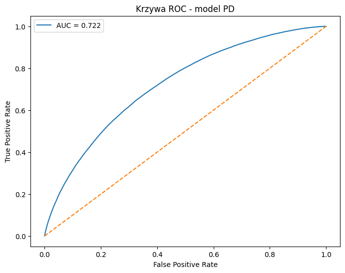

```
Macierz pomyłek dla progu 0.5:
[[157742  89310]
 [ 19163  41305]]

Raport klasyfikacji:
              precision    recall  f1-score   support

           0       0.89      0.64      0.74    247052
           1       0.32      0.68      0.43     60468

    accuracy                           0.65    307520
   macro avg       0.60      0.66      0.59    307520
weighted avg       0.78      0.65      0.68    307520
```

```python
nazwa_najlepszego_modelu = wyniki_modeli.loc[0, "model"]
najlepszy_model_pd = modele_pd[nazwa_najlepszego_modelu]

print("Najlepszy model PD:", nazwa_najlepszego_modelu)

PD_test = najlepszy_model_pd.predict_proba(X_test)[:, 1]

auc_pd = roc_auc_score(y_test, PD_test)
gini_pd = 2 * auc_pd - 1

print("AUC:", auc_pd)
print("Gini:", gini_pd)

fpr, tpr, thresholds = roc_curve(y_test, PD_test)

plt.figure(figsize=(8, 6))
plt.plot(fpr, tpr, label=f"AUC = {auc_pd:.3f}")
plt.plot([0, 1], [0, 1], linestyle="--")
plt.xlabel("False Positive Rate")
plt.ylabel("True Positive Rate")
plt.title("Krzywa ROC - model PD")
plt.legend()
plt.show()

pred_05 = (PD_test >= 0.5).astype(int)

print("Macierz pomyłek dla progu 0.5:")
print(confusion_matrix(y_test, pred_05))

print("\nRaport klasyfikacji:")
print(classification_report(y_test, pred_05))
```

Najlepszym modelem PD okazał się LightGBM. Model uzyskał AUC na poziomie 0,722 oraz współczynnik Giniego równy 0,444. Oznacza to, że model ma umiarkowaną zdolność rozróżniania kredytu dobrego od kredytu zakończonego defaultem. Wynik jest wyraźnie lepszy od klasyfikacji losowej, dla której AUC wynosi 0,5.

Krzywa ROC znajduje się powyżej linii losowej klasyfikacji, co potwierdza, że model poprawnie porządkuje obserwację według ryzyka defaultu. Im wyżej położona jest krzywa ROC, tym lepsza jest jakość modelu rankingowego.

Dla progu decyzyjnego 0,5 model osiąga recall dla klasy default na poziomie 0,68. Oznacza to, że model wykrywa około 68% kredytów, które faktycznie zakończyły się defaultem. Precision dla klasy default wynosi 0,32, co oznacza, że część kredytów oznaczonych jako ryzykowne nie kończy się defaultem.

Accuracy wynosi 0,65, jednak przy niezbalansowanej zmiennej objaśnianej nie jest to najważniejsza miara oceny. Większe znaczenie mają AUC, Gini oraz recall dla klasy default. Na tej podstawie model LightGBM można uznać za najlepszy spośród porównywanych modeli i wykorzystać go do dalszego szacowania prawdopodobieństwa defaultu

## 9. Kalibracja PD

W modelowaniu ryzyka kredytowego model powinien nie tylko dobrze porządkować klientów według ryzyka, ale też generować prawdopodobieństwa w poprawnej skali.

Dlatego sprawdzamy:

- krzywą kalibracji,
- Brier Score,
- decyle ryzyka.

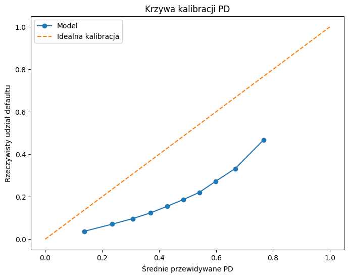

```
Brier Score: 0.2135792830493728
```

|  | decyl_PD | liczba_obserwacji | srednie_PD | rzeczywisty_udzial_defaultu |
| --- | --- | --- | --- | --- |
| 0 | 1 | 30752 | 0.1371 | 0.0373 |
| 1 | 2 | 30752 | 0.2359 | 0.0710 |
| 2 | 3 | 30752 | 0.3074 | 0.0969 |
| 3 | 4 | 30752 | 0.3700 | 0.1239 |
| 4 | 5 | 30752 | 0.4293 | 0.1556 |
| 5 | 6 | 30752 | 0.4859 | 0.1870 |
| 6 | 7 | 30752 | 0.5416 | 0.2208 |
| 7 | 8 | 30752 | 0.5993 | 0.2731 |
| 8 | 9 | 30752 | 0.6673 | 0.3325 |
| 9 | 10 | 30752 | 0.7675 | 0.4683 |

```python
udzial_defaultow, srednie_przewidywane_pd = calibration_curve(
    y_test,
    PD_test,
    n_bins=10,
    strategy="quantile"
)

plt.figure(figsize=(8, 6))
plt.plot(srednie_przewidywane_pd, udzial_defaultow, marker="o", label="Model")
plt.plot([0, 1], [0, 1], linestyle="--", label="Idealna kalibracja")
plt.xlabel("Średnie przewidywane PD")
plt.ylabel("Rzeczywisty udział defaultu")
plt.title("Krzywa kalibracji PD")
plt.legend()
plt.show()

print("Brier Score:", brier_score_loss(y_test, PD_test))

analiza_decyli = pd.DataFrame({
    "czy_default": y_test.values,
    "PD": PD_test
})

analiza_decyli["decyl_PD"] = pd.qcut(
    analiza_decyli["PD"],
    10,
    labels=False,
    duplicates="drop"
) + 1

podsumowanie_decyli = (
    analiza_decyli
    .groupby("decyl_PD")
    .agg(
        liczba_obserwacji=("czy_default", "size"),
        srednie_PD=("PD", "mean"),
        rzeczywisty_udzial_defaultu=("czy_default", "mean")
    )
    .reset_index()
)

display(podsumowanie_decyli)
```

Krzywa kalibracji znajduje się wyraźnie poniżej linii idealnej kalibracji. Oznacza to, że model przewiduje wyższe prawdopodobieństwo defaultu niż rzeczywiście obserwuję w danych. Przykładowo w najwyższym decylu średnie przewidywane PD wynosi około 0,77, a rzeczywisty udział defaultu wynosi około 0,47. Jednocześnie analiza decyli pokazuje, że model dobrze szereguje obserwację według ryzyka. Wraz ze wzrostem decyla PD rośnie rzeczywisty udział defaultu: od około 3,7% w najniższym decylu do około 46,8% w najwyższym decylu. Oznacza to, że model skutecznie odróżnia kredyt mniej ryzykowny od bardziej ryzykownego.

Brier Score wynosi około 0,214. Wartość ta wskazuje, że jakość przewidywanych prawdopodobieństw jest umiarkowana. Model może być użyteczny jako model rankingowy, ale przed wykorzystaniem PD jako bezpośredniego prawdopodobieństwa warto rozważyć dodatkową kalibrację.

# Część B: EAD

**EAD** oznacza ekspozycję w momencie defaultu.

W tym projekcie przyjmuję uproszczenie:

[ EAD = funded_amnt ]

Jest to rozsądne przybliżenie, ponieważ `funded_amnt` oznacza kwotę finansowania wypłaconą klientowi.

```python
if "funded_amnt" not in dane_model.columns:
    raise ValueError("Brakuje kolumny funded_amnt. Nie można wyznaczyć EAD.")

dane_model["EAD"] = dane_model["funded_amnt"]

print("Statystyki EAD:")
display(dane_model["EAD"].describe())
```

```
Statystyki EAD:
```

```
count   1,230,079.0000
mean       14,577.2311
std         8,722.4802
min           500.0000
25%         8,000.0000
50%        12,000.0000
75%        20,000.0000
max        40,000.0000
Name: EAD, dtype: float64
```

# Część C: Modelowanie LGD

**LGD** oznacza stratę w przypadku defaultu.

Najpierw obliczam stopę odzysku:

[ recovery_rate = \frac{recoveries}{EAD} ]

Następnie:

[ LGD = 1 - recovery_rate ]

Model LGD buduję tylko na kredytach, które weszły w default.

```
Liczba obserwacji do modelu LGD: 262447

Statystyki LGD:
```

```
count   262,447.0000
mean          0.9268
std           0.0940
min           0.0000
25%           0.8897
50%           0.9416
75%           1.0000
max           1.0000
Name: LGD, dtype: float64
```

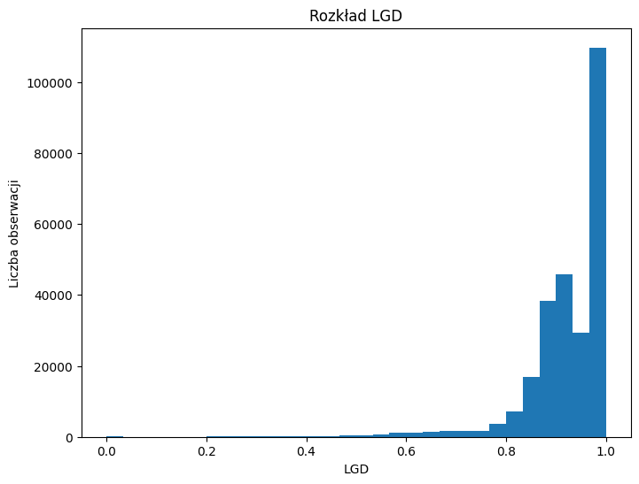

```python
dane_lgd = dane[
    dane["loan_status"].isin([
        "Charged Off",
        "Default",
        "Does not meet the credit policy. Status:Charged Off"
    ])
].copy()

# EAD (tak jak wcześniej)
dane_lgd["EAD"] = dane_lgd["funded_amnt"]

# Recovery rate
dane_lgd["recovery_rate"] = (
    dane_lgd["recoveries"] /
    dane_lgd["EAD"].replace(0, np.nan)
)

dane_lgd["recovery_rate"] = dane_lgd["recovery_rate"].clip(0, 1)

# LGD
dane_lgd["LGD"] = 1 - dane_lgd["recovery_rate"]
dane_lgd["LGD"] = dane_lgd["LGD"].clip(0, 1)

print("Liczba obserwacji do modelu LGD:", dane_lgd.shape[0])

print("\nStatystyki LGD:")
display(dane_lgd["LGD"].describe())

plt.figure(figsize=(8, 6))
plt.hist(dane_lgd["LGD"].dropna(), bins=30)
plt.xlabel("LGD")
plt.ylabel("Liczba obserwacji")
plt.title("Rozkład LGD")
plt.show()
```

Rozkład LGD jest silnie skoncentrowany w pobliżu wartości 1, co oznacza, że w większości przypadków bank ponosi niemal pełną stratę w przypadku defaultu. Średnia LGD wynosi około 0,93, co wskazuje na bardzo niski poziom odzysków. Model LGD w tym przypadku będzie miał ograniczoną zmienność, ponieważ większość obserwacji znajduje się blisko maksymalnej straty.

## 10. Testowanie różnych modeli LGD

LGD jest zwykle trudniejsze do modelowania niż PD, ponieważ odzyski po defaultcie zależą od wielu czynników niedostępnych w danych.

Porównuję:

- Linear Regression,
- Ridge,
- Random Forest Regressor,
- Gradient Boosting Regressor,
- XGBoost Regressor, jeśli jest dostępny,
- LightGBM Regressor, jeśli jest dostępny.

Metryki:

- MAE,
- RMSE,
- R².

```python
# Dane do LGD biorę z oryginalnego zbioru i tworzę brakujące zmienne pochodne
dane_lgd = dane[
    dane["loan_status"].isin(statusy_default)
].copy()

dane_lgd["int_rate"] = oczysc_kolumne_procentowa(dane_lgd["int_rate"])
dane_lgd["revol_util"] = oczysc_kolumne_procentowa(dane_lgd["revol_util"])
dane_lgd["term_months"] = oczysc_okres_kredytu(dane_lgd["term"])

dane_lgd["credit_history_months"] = oblicz_miesiace_od_daty(
    dane_lgd["earliest_cr_line"]
)

dane_lgd["installment_to_income"] = (
    dane_lgd["installment"] / dane_lgd["annual_inc"].replace(0, np.nan)
)

dane_lgd["loan_to_income"] = (
    dane_lgd["loan_amnt"] / dane_lgd["annual_inc"].replace(0, np.nan)
)

dane_lgd["funded_to_income"] = (
    dane_lgd["funded_amnt"] / dane_lgd["annual_inc"].replace(0, np.nan)
)

dane_lgd["revol_bal_to_income"] = (
    dane_lgd["revol_bal"] / dane_lgd["annual_inc"].replace(0, np.nan)
)

dane_lgd["EAD"] = dane_lgd["funded_amnt"]

dane_lgd["recovery_rate"] = (
    dane_lgd["recoveries"] / dane_lgd["EAD"].replace(0, np.nan)
).clip(0, 1)

dane_lgd["LGD"] = (1 - dane_lgd["recovery_rate"]).clip(0, 1)

dane_lgd = dane_lgd.dropna(subset=zmienne_objasniajace + ["LGD"]).copy()

# Zmienne objaśniające dla LGD
X_lgd = dane_lgd[zmienne_objasniajace].copy()
y_lgd = dane_lgd["LGD"].copy()


# Podział danych na zbiór treningowy i testowy
X_train_lgd, X_test_lgd, y_train_lgd, y_test_lgd = train_test_split(
    X_lgd,
    y_lgd,
    test_size=0.25,
    random_state=RANDOM_STATE
)


modele_lgd = {
    "Linear Regression": Pipeline(steps=[
        ("preprocessing", preprocessing_liniowy),
        ("model", LinearRegression())
    ]),

    "Ridge": Pipeline(steps=[
        ("preprocessing", preprocessing_liniowy),
        ("model", Ridge(alpha=1.0))
    ]),

    "Random Forest": Pipeline(steps=[
        ("preprocessing", preprocessing_drzewo),
        ("model", RandomForestRegressor(
            n_estimators=300,
            max_depth=10,
            min_samples_leaf=30,
            random_state=RANDOM_STATE,
            n_jobs=-1
        ))
    ]),

    "Gradient Boosting": Pipeline(steps=[
        ("preprocessing", preprocessing_drzewo),
        ("model", GradientBoostingRegressor(
            n_estimators=300,
            learning_rate=0.05,
            max_depth=3,
            random_state=RANDOM_STATE
        ))
    ]),

    "XGBoost": Pipeline(steps=[
        ("preprocessing", preprocessing_drzewo),
        ("model", XGBRegressor(
            n_estimators=300,
            max_depth=4,
            learning_rate=0.05,
            subsample=0.8,
            colsample_bytree=0.8,
            objective="reg:squarederror",
            random_state=RANDOM_STATE,
            n_jobs=-1
        ))
    ]),

    "LightGBM": Pipeline(steps=[
        ("preprocessing", preprocessing_drzewo),
        ("model", LGBMRegressor(
            n_estimators=300,
            learning_rate=0.05,
            num_leaves=31,
            subsample=0.8,
            colsample_bytree=0.8,
            random_state=RANDOM_STATE,
            n_jobs=-1
        ))
    ])
}


wyniki_lgd = []
wytrenowane_modele_lgd = {}

for nazwa_modelu, model in modele_lgd.items():
    print("Trening modelu LGD:", nazwa_modelu)

    model.fit(X_train_lgd, y_train_lgd)

    predykcja_lgd = model.predict(X_test_lgd)
    predykcja_lgd = np.clip(predykcja_lgd, 0, 1)

    mae = mean_absolute_error(y_test_lgd, predykcja_lgd)
    rmse = np.sqrt(mean_squared_error(y_test_lgd, predykcja_lgd))
    r2 = r2_score(y_test_lgd, predykcja_lgd)

    wyniki_lgd.append({
        "model": nazwa_modelu,
        "MAE": mae,
        "RMSE": rmse,
        "R2": r2
    })

    wytrenowane_modele_lgd[nazwa_modelu] = model


wyniki_lgd = (
    pd.DataFrame(wyniki_lgd)
    .sort_values("MAE")
    .reset_index(drop=True)
)

display(wyniki_lgd)


nazwa_najlepszego_modelu_lgd = wyniki_lgd.loc[0, "model"]
najlepszy_model_lgd = wytrenowane_modele_lgd[nazwa_najlepszego_modelu_lgd]

print("Najlepszy model LGD:", nazwa_najlepszego_modelu_lgd)
```

[output not shown]

|  | model | MAE | RMSE | R2 |
| --- | --- | --- | --- | --- |
| 0 | LightGBM | 0.0627 | 0.0934 | 0.0183 |
| 1 | XGBoost | 0.0627 | 0.0934 | 0.0182 |
| 2 | Gradient Boosting | 0.0628 | 0.0935 | 0.0166 |
| 3 | Random Forest | 0.0628 | 0.0935 | 0.0162 |
| 4 | Ridge | 0.0629 | 0.0935 | 0.0152 |
| 5 | Linear Regression | 0.0629 | 0.0935 | 0.0152 |

```
Najlepszy model LGD: LightGBM
```

## 11. Ocena najlepszego modelu LGD

Porównuję rzeczywiste LGD z przewidywanym LGD.

```
Najlepszy model LGD: LightGBM
MAE: 0.06268114386575634
RMSE: 0.09338950871735006
R2: 0.018311017259016293
```

|  | decyl_predykcji | liczba_obserwacji | srednie_LGD_rzeczywiste | srednie_LGD_przewidywane |
| --- | --- | --- | --- | --- |
| 0 | 1 | 6047 | 0.9025 | 0.9004 |
| 1 | 2 | 6047 | 0.9124 | 0.9125 |
| 2 | 3 | 6047 | 0.9168 | 0.9179 |
| 3 | 4 | 6047 | 0.9223 | 0.9220 |
| 4 | 5 | 6047 | 0.9238 | 0.9254 |
| 5 | 6 | 6046 | 0.9295 | 0.9284 |
| 6 | 7 | 6047 | 0.9299 | 0.9312 |
| 7 | 8 | 6047 | 0.9337 | 0.9342 |
| 8 | 9 | 6047 | 0.9389 | 0.9381 |
| 9 | 10 | 6047 | 0.9477 | 0.9464 |

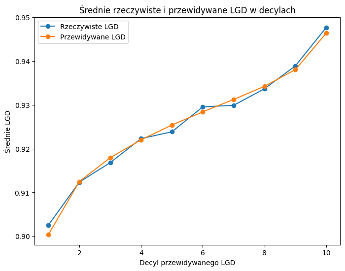

```python
# Ocena najlepszego modelu LGD na zbiorze testowym
predykcja_lgd_test = najlepszy_model_lgd.predict(X_test_lgd)
predykcja_lgd_test = np.clip(predykcja_lgd_test, 0, 1)

mae_lgd = mean_absolute_error(y_test_lgd, predykcja_lgd_test)
rmse_lgd = np.sqrt(mean_squared_error(y_test_lgd, predykcja_lgd_test))
r2_lgd = r2_score(y_test_lgd, predykcja_lgd_test)

print("Najlepszy model LGD:", nazwa_najlepszego_modelu_lgd)
print("MAE:", mae_lgd)
print("RMSE:", rmse_lgd)
print("R2:", r2_lgd)

analiza_lgd = pd.DataFrame({
    "LGD_rzeczywiste": y_test_lgd.values,
    "LGD_przewidywane": predykcja_lgd_test
})

analiza_lgd["decyl_predykcji"] = pd.qcut(
    analiza_lgd["LGD_przewidywane"],
    10,
    labels=False,
    duplicates="drop"
) + 1

podsumowanie_lgd = (
    analiza_lgd
    .groupby("decyl_predykcji")
    .agg(
        liczba_obserwacji=("LGD_rzeczywiste", "size"),
        srednie_LGD_rzeczywiste=("LGD_rzeczywiste", "mean"),
        srednie_LGD_przewidywane=("LGD_przewidywane", "mean")
    )
    .reset_index()
)

display(podsumowanie_lgd)

plt.figure(figsize=(8, 6))
plt.plot(
    podsumowanie_lgd["decyl_predykcji"],
    podsumowanie_lgd["srednie_LGD_rzeczywiste"],
    marker="o",
    label="Rzeczywiste LGD"
)
plt.plot(
    podsumowanie_lgd["decyl_predykcji"],
    podsumowanie_lgd["srednie_LGD_przewidywane"],
    marker="o",
    label="Przewidywane LGD"
)

plt.xlabel("Decyl przewidywanego LGD")
plt.ylabel("Średnie LGD")
plt.title("Średnie rzeczywiste i przewidywane LGD w decylach")
plt.legend()
plt.show()
```

Model LGD bardzo dobrze odwzorowuje średni poziom straty, co widać po niemal pokrywających się liniach dla wartości rzeczywistych i przewidywanych w decylach. Jednocześnie bardzo niski współczynnik R² wskazuje, że model ma ograniczoną zdolność do wyjaśniania zróżnicowania LGD na poziomie pojedynczej obserwacji. Wynika to z faktu, że LGD jest silnie skoncentrowane blisko wartości 1, co ogranicza zmienność zmiennej objaśnianej. Również tak niskie R² jest spowodowane ograniczoną liczbą zmiennych objaśniających w tym zbiorze.

## 12. Alternatywne podejście: dwustopniowy model odzysków

LGD można modelować także pośrednio przez odzyski:

1. model klasyfikacyjny: czy wystąpi jakikolwiek odzysk,
2. model regresyjny: jaka będzie stopa odzysku, jeśli odzysk wystąpi.

To podejście bywa skuteczniejsze, jeśli wiele obserwacji ma zerowe odzyski.

```python
dane_lgd["czy_odzysk"] = np.where(dane_lgd["recoveries"] > 0, 1, 0)

print("Udział obserwacji z odzyskiem:")
display(dane_lgd["czy_odzysk"].value_counts(normalize=True))


# Etap 1: model klasyfikacyjny — czy wystąpi jakikolwiek odzysk
X_odzysk = dane_lgd[zmienne_objasniajace].copy()
y_odzysk = dane_lgd["czy_odzysk"].copy()

X_train_odzysk, X_test_odzysk, y_train_odzysk, y_test_odzysk = train_test_split(
    X_odzysk,
    y_odzysk,
    test_size=0.25,
    random_state=RANDOM_STATE,
    stratify=y_odzysk
)

model_czy_odzysk = Pipeline(steps=[
    ("preprocessing", preprocessing_drzewo),
    ("model", GradientBoostingClassifier(
        n_estimators=300,
        learning_rate=0.05,
        max_depth=3,
        random_state=RANDOM_STATE
    ))
])

model_czy_odzysk.fit(X_train_odzysk, y_train_odzysk)

p_odzysk = model_czy_odzysk.predict_proba(X_test_odzysk)[:, 1]

auc_odzysk = roc_auc_score(y_test_odzysk, p_odzysk)
gini_odzysk = 2 * auc_odzysk - 1

print("AUC modelu czy_odzysk:", auc_odzysk)
print("Gini modelu czy_odzysk:", gini_odzysk)


# Etap 2: model regresyjny — stopa odzysku pod warunkiem, że odzysk wystąpił
dane_z_odzyskiem = dane_lgd[dane_lgd["recoveries"] > 0].copy()

X_recovery_rate = dane_z_odzyskiem[zmienne_objasniajace].copy()
y_recovery_rate = dane_z_odzyskiem["recovery_rate"].copy()

X_train_rr, X_test_rr, y_train_rr, y_test_rr = train_test_split(
    X_recovery_rate,
    y_recovery_rate,
    test_size=0.25,
    random_state=RANDOM_STATE
)

model_recovery_rate = Pipeline(steps=[
    ("preprocessing", preprocessing_drzewo),
    ("model", GradientBoostingRegressor(
        n_estimators=300,
        learning_rate=0.05,
        max_depth=3,
        random_state=RANDOM_STATE
    ))
])

model_recovery_rate.fit(X_train_rr, y_train_rr)

predykcja_recovery_rate = model_recovery_rate.predict(X_test_rr)
predykcja_recovery_rate = np.clip(predykcja_recovery_rate, 0, 1)

mae_rr = mean_absolute_error(y_test_rr, predykcja_recovery_rate)
rmse_rr = np.sqrt(mean_squared_error(y_test_rr, predykcja_recovery_rate))
r2_rr = r2_score(y_test_rr, predykcja_recovery_rate)

print("\nLiczba obserwacji z odzyskiem:", dane_z_odzyskiem.shape[0])
print("MAE modelu recovery_rate:", mae_rr)
print("RMSE modelu recovery_rate:", rmse_rr)
print("R2 modelu recovery_rate:", r2_rr)
```

```
Udział obserwacji z odzyskiem:
```

```
czy_odzysk
1   0.6858
0   0.3142
Name: proportion, dtype: float64
```

```
AUC modelu czy_odzysk: 0.6480014639747306
Gini modelu czy_odzysk: 0.29600292794946115

Liczba obserwacji z odzyskiem: 165880
MAE modelu recovery_rate: 0.056526974549169974
RMSE modelu recovery_rate: 0.09414474872986998
R2 modelu recovery_rate: 0.026831563770637556
```

Model dwustopniowy pokazuje umiarkowaną skuteczność. Model klasyfikacyjny osiąga AUC na poziomie około 0,65, co oznacza ograniczoną zdolność do rozróżniania przypadków z odzyskiem i bez odzysku. Model regresyjny dla stopy odzysku osiąga niskie R², co wskazuje na niewielką zdolność do wyjaśniania zróżnicowania wysokości odzysków.

Jednocześnie niska wartość MAE sugeruje, że model dobrze przybliża średni poziom odzysków. Podobnie jak w przypadku LGD, zmienna recovery_rate ma ograniczoną zmienność, co utrudnia budowę dokładnego modelu na poziomie pojedynczej obserwacji.

W rezultacie podejście dwustopniowe nie przynosi istotnej poprawy względem prostszego modelowania LGD i ma głównie wartość interpretacyjną.

# Część D: Expected Loss

Dla każdej obserwacji ze zbioru testowego liczę:

[ EL = PD x LGD x EAD ]

Gdzie:

- PD pochodzi z najlepszego modelu klasyfikacyjnego,
- LGD pochodzi z najlepszego modelu regresyjnego,
- EAD = `funded_amnt`.

```python
wyniki = X_test.copy()

wyniki["czy_default"] = y_test.values
wyniki["PD"] = PD_test
wyniki["LGD"] = np.clip(najlepszy_model_lgd.predict(X_test), 0, 1)
wyniki["EAD"] = X_test["funded_amnt"].values
wyniki["EL"] = wyniki["PD"] * wyniki["LGD"] * wyniki["EAD"]

display(wyniki[["PD", "LGD", "EAD", "EL"]].describe())

print("Całkowite EAD portfela testowego:", wyniki["EAD"].sum())
print("Całkowite Expected Loss portfela testowego:", wyniki["EL"].sum())
print("Średnie PD:", wyniki["PD"].mean())
print("Średnie LGD:", wyniki["LGD"].mean())
print("Średni EL na kredyt:", wyniki["EL"].mean())
print("EL / EAD:", wyniki["EL"].sum() / wyniki["EAD"].sum())
```

|  | PD | LGD | EAD | EL |
| --- | --- | --- | --- | --- |
| count | 307,520.0000 | 307,520.0000 | 307,520.0000 | 307,520.0000 |
| mean | 0.4541 | 0.9294 | 14,595.9425 | 6,434.1812 |
| std | 0.1888 | 0.0125 | 8,724.8426 | 5,208.7447 |
| min | 0.0321 | 0.7707 | 500.0000 | 33.8513 |
| 25% | 0.3077 | 0.9222 | 8,000.0000 | 2,458.0511 |
| 50% | 0.4580 | 0.9306 | 12,175.0000 | 4,820.0449 |
| 75% | 0.5989 | 0.9378 | 20,000.0000 | 9,090.5844 |
| max | 0.9096 | 0.9911 | 40,000.0000 | 32,845.7209 |

```
Całkowite EAD portfela testowego: 4488544250
Całkowite Expected Loss portfela testowego: 1978639402.5690832
Średnie PD: 0.4541282271664387
Średnie LGD: 0.9294132702704075
Średni EL na kredyt: 6434.181199821421
EL / EAD: 0.4408198499032472
```

Oczekiwana strata portfela (EL) stanowi około 44% całkowitej ekspozycji (EAD), co wynika z relatywnie wysokiego średniego PD (ok. 45%) oraz bardzo wysokiego LGD (ok. 93%). Oznacza to, że analizowany portfel charakteryzuje się wysokim poziomem ryzyka kredytowego.

Średnia strata na pojedynczy kredyt wynosi około 6,4 tys., co przy średnim EAD na poziomie około 14,6 tys. wskazuje na istotny udział strat w wartości ekspozycji. Wyniki te są spójne z wcześniejszymi obserwacjami, wysoki LGD oraz umiarkowana zdolność modelu PD do rozróżniania ryzyka przekładają się na relatywnie wysoką oczekiwaną stratę.

W praktyce oznacza to, że portfel zawiera znaczną część kredytów o podwyższonym ryzyku, co może wymagać zaostrzenia polityki kredytowej lub lepszego dopasowania cen (oprocentowania) do poziomu ryzyka.

# Część E: Analiza portfela

W tej części sprawdzam, które kredyty oraz segmenty portfela generują największe ryzyko.

```python
top_ryzyko = wyniki.sort_values("EL", ascending=False).head(20)

kolumny_top = ["PD", "LGD", "EAD", "EL"] + [
    c for c in ["grade", "sub_grade", "int_rate", "dti", "annual_inc", "purpose"]
    if c in top_ryzyko.columns
]

display(top_ryzyko[kolumny_top])
```

|  | PD | LGD | EAD | EL | grade | sub_grade | int_rate | dti | annual_inc | purpose |
| --- | --- | --- | --- | --- | --- | --- | --- | --- | --- | --- |
| 1505682 | 0.8523 | 0.9634 | 40000 | 32,845.7209 | D | D3 | 19.0300 | 12.9600 | 45,000.0000 | debt_consolidation |
| 1569861 | 0.8624 | 0.9297 | 40000 | 32,069.0226 | F | F5 | 30.7500 | 26.5700 | 84,000.0000 | debt_consolidation |
| 1548937 | 0.8676 | 0.9216 | 40000 | 31,983.8810 | G | G5 | 30.9900 | 17.7800 | 83,000.0000 | debt_consolidation |
| 1475272 | 0.8420 | 0.9421 | 40000 | 31,729.2948 | F | F5 | 30.7500 | 25.2000 | 120,000.0000 | small_business |
| 1658947 | 0.8614 | 0.9199 | 40000 | 31,692.9277 | F | F5 | 30.7400 | 23.2700 | 117,000.0000 | debt_consolidation |
| 2259599 | 0.8259 | 0.9405 | 40000 | 31,071.8859 | E | E5 | 26.3000 | 28.6500 | 78,000.0000 | debt_consolidation |
| 1385888 | 0.8398 | 0.9239 | 40000 | 31,036.1310 | E | E5 | 26.2400 | 1.8500 | 90,000.0000 | credit_card |
| 354011 | 0.8375 | 0.9260 | 40000 | 31,019.5686 | E | E3 | 24.8400 | 27.6800 | 98,600.0000 | debt_consolidation |
| 2215946 | 0.8110 | 0.9556 | 40000 | 30,999.9704 | E | E1 | 22.9100 | 16.2600 | 87,000.0000 | small_business |
| 2239482 | 0.8326 | 0.9306 | 40000 | 30,990.7727 | D | D1 | 17.0900 | 35.4600 | 53,000.0000 | debt_consolidation |
| 1352386 | 0.8267 | 0.9328 | 40000 | 30,848.3215 | E | E1 | 22.7400 | 20.7900 | 102,500.0000 | debt_consolidation |
| 617209 | 0.8508 | 0.9038 | 40000 | 30,756.0028 | E | E3 | 23.3200 | 30.2000 | 120,000.0000 | debt_consolidation |
| 322644 | 0.7937 | 0.9667 | 40000 | 30,690.5997 | D | D3 | 19.4200 | 74.7200 | 37,984.4900 | debt_consolidation |
| 1594150 | 0.8630 | 0.9332 | 38000 | 30,601.5369 | G | G3 | 30.8900 | 1.9800 | 250,000.0000 | major_purchase |
| 271657 | 0.7941 | 0.9591 | 40000 | 30,464.7981 | C | C3 | 14.5200 | 18.1100 | 119,545.0000 | debt_consolidation |
| 1605506 | 0.8231 | 0.9191 | 40000 | 30,262.0277 | F | F1 | 28.7200 | 19.9500 | 135,000.0000 | debt_consolidation |
| 565509 | 0.8053 | 0.9374 | 40000 | 30,195.2771 | C | C5 | 15.5900 | 5.6800 | 83,000.0000 | major_purchase |
| 1556837 | 0.8990 | 0.9560 | 35000 | 30,080.5209 | F | F4 | 30.6500 | 18.4800 | 75,000.0000 | small_business |
| 1425525 | 0.8091 | 0.9262 | 40000 | 29,975.3634 | E | E2 | 23.9900 | 27.6200 | 100,000.0000 | small_business |
| 2167640 | 0.7585 | 0.9869 | 40000 | 29,941.7949 | B | B3 | 10.4200 | 8.0700 | 65,000.0000 | small_business |

Największe ryzyko w portfelu generują kredyty o wysokiej ekspozycji (EAD bliskiej maksymalnej wartości), wysokim prawdopodobieństwie defaultu oraz bardzo wysokim LGD. W szczególności dominują tu kredyty o niskich ocenach jakości (grade D–G), wysokim oprocentowaniu oraz często przeznaczone na konsolidację zadłużenia (debt_consolidation) lub działalność gospodarczą (small_business).

Widać również, że wysokie ryzyko nie wynika wyłącznie z jednej zmiennej, lecz z ich kombinacji: wysoki PD, wysoki LGD oraz duża kwota kredytu razem prowadzą do najwyższych wartości Expected Loss. Oznacza to, że zarządzanie ryzykiem powinno koncentrować się na ograniczaniu ekspozycji w tych segmentach lub odpowiednim ich wycenianiu.

## Analiza według ratingu kredytowego

Jeżeli w danych występuje zmienna `grade`, sprawdzam ryzyko według klas ratingowych.

|  | grade | liczba_kredytow | srednie_PD | srednie_LGD | suma_EAD | suma_EL | EL_do_EAD |
| --- | --- | --- | --- | --- | --- | --- | --- |
| 0 | A | 53513 | 0.1911 | 0.9396 | 749680150 | 134,755,982.9846 | 0.1798 |
| 1 | B | 89690 | 0.3683 | 0.9343 | 1200469100 | 421,568,617.4565 | 0.3512 |
| 2 | C | 86915 | 0.5210 | 0.9275 | 1247703000 | 618,085,556.8739 | 0.4954 |
| 3 | D | 45804 | 0.6207 | 0.9233 | 709935850 | 418,475,496.6507 | 0.5895 |
| 4 | E | 21745 | 0.7007 | 0.9147 | 388660850 | 253,020,413.1065 | 0.6510 |
| 5 | F | 7647 | 0.7469 | 0.9075 | 146375575 | 100,218,085.4099 | 0.6847 |
| 6 | G | 2206 | 0.7824 | 0.9067 | 45719725 | 32,515,250.0870 | 0.7112 |

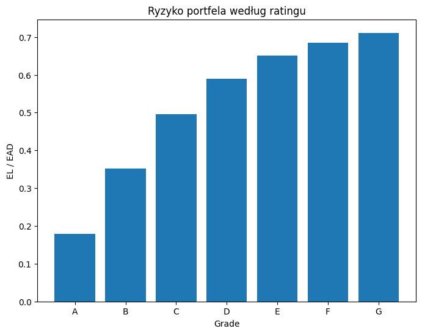

```python
if "grade" in wyniki.columns:
    analiza_grade = wyniki.groupby("grade").agg(
        liczba_kredytow=("EL", "size"),
        srednie_PD=("PD", "mean"),
        srednie_LGD=("LGD", "mean"),
        suma_EAD=("EAD", "sum"),
        suma_EL=("EL", "sum")
    ).reset_index().sort_values("grade")

    analiza_grade["EL_do_EAD"] = analiza_grade["suma_EL"] / analiza_grade["suma_EAD"]

    display(analiza_grade)

    plt.figure(figsize=(8, 6))
    plt.bar(analiza_grade["grade"], analiza_grade["EL_do_EAD"])
    plt.xlabel("Grade")
    plt.ylabel("EL / EAD")
    plt.title("Ryzyko portfela według ratingu")
    plt.show()
else:
    print("Brak kolumny grade w danych.")
```

Ryzyko portfela rośnie systematycznie wraz z pogorszeniem ratingu kredytowego. Dla najlepszych kredytów (grade A) relacja EL do EAD wynosi około 18%, natomiast dla najgorszych (grade G) przekracza 70%. Oznacza to, że rating bardzo dobrze różnicuje poziom ryzyka.

Wraz ze spadkiem jakości kredytowej rośnie przede wszystkim PD, natomiast LGD pozostaje na zbliżonym poziomie. W efekcie to właśnie wzrost prawdopodobieństwa defaultu jest głównym czynnikiem zwiększającym oczekiwaną stratę.

Największy udział w całkowitej stracie portfela generują kredyty o średnich ratingach (B–D), ponieważ łączą relatywnie wysokie ryzyko z dużym wolumenem ekspozycji. Z kolei kredyty o najgorszych ratingach (E–G), mimo najwyższego ryzyka jednostkowego, mają mniejszy udział w portfelu.

## Analiza według celu kredytu

Jeżeli w danych występuje zmienna `purpose`, sprawdzamy, które cele kredytowania są najbardziej ryzykowne.

```python
if "purpose" in wyniki.columns:
    analiza_purpose = wyniki.groupby("purpose").agg(
        liczba_kredytow=("EL", "size"),
        srednie_PD=("PD", "mean"),
        srednie_LGD=("LGD", "mean"),
        suma_EAD=("EAD", "sum"),
        suma_EL=("EL", "sum")
    ).reset_index()

    analiza_purpose["EL_do_EAD"] = analiza_purpose["suma_EL"] / analiza_purpose["suma_EAD"]
    analiza_purpose = analiza_purpose.sort_values("EL_do_EAD", ascending=False)

    display(analiza_purpose.head(20))
else:
    print("Brak kolumny purpose w danych.")
```

|  | purpose | liczba_kredytow | srednie_PD | srednie_LGD | suma_EAD | suma_EL | EL_do_EAD |
| --- | --- | --- | --- | --- | --- | --- | --- |
| 11 | small_business | 3668 | 0.5892 | 0.9287 | 56357050 | 32,173,785.1713 | 0.5709 |
| 8 | moving | 2109 | 0.4893 | 0.9259 | 16741800 | 8,188,614.1902 | 0.4891 |
| 9 | other | 17521 | 0.4756 | 0.9275 | 175140150 | 83,744,585.3356 | 0.4782 |
| 7 | medical | 3447 | 0.4697 | 0.9264 | 31330975 | 14,686,292.0543 | 0.4687 |
| 10 | renewable_energy | 211 | 0.4852 | 0.9257 | 2202975 | 1,030,723.1446 | 0.4679 |
| 5 | house | 1667 | 0.4909 | 0.9277 | 26136275 | 12,199,985.8388 | 0.4668 |
| 2 | debt_consolidation | 179189 | 0.4741 | 0.9287 | 2758793275 | 1,259,557,361.6931 | 0.4566 |
| 12 | vacation | 2099 | 0.4409 | 0.9272 | 13113125 | 5,976,748.6541 | 0.4558 |
| 6 | major_purchase | 6689 | 0.4276 | 0.9300 | 81155225 | 36,420,804.7452 | 0.4488 |
| 4 | home_improvement | 19667 | 0.4141 | 0.9287 | 283125875 | 117,867,086.4858 | 0.4163 |
| 1 | credit_card | 67323 | 0.4046 | 0.9323 | 1008749125 | 393,146,665.2292 | 0.3897 |
| 0 | car | 3263 | 0.3752 | 0.9319 | 29143525 | 11,340,096.1260 | 0.3891 |
| 3 | educational | 107 | 0.4157 | 0.9342 | 675275 | 261,617.7456 | 0.3874 |
| 13 | wedding | 560 | 0.3504 | 0.9276 | 5879600 | 2,045,036.1553 | 0.3478 |

Najbardziej ryzykowne cele kredytowania to small_business oraz moving, dla których relacja EL do EAD przekracza 0,48–0,57. Wysokie ryzyko wynika głównie z podwyższonego PD, przy podobnym poziomie LGD we wszystkich segmentach.

Największy wpływ na całkowitą stratę portfela ma jednak segment debt_consolidation, który łączy umiarkowanie wysokie ryzyko z bardzo dużym wolumenem kredytów i ekspozycji.

Najniższe ryzyko obserwuję w segmentach takich jak wedding, educational czy car, gdzie zarówno PD, jak i EL/EAD są relatywnie niskie.

Wyniki wskazują, że ryzyko portfela zależy nie tylko od poziomu ryzyka jednostkowego, ale również od struktury portfela i koncentracji ekspozycji w poszczególnych celach kredytowania.

# Część F: Symulacja strategii kredytowej

Sprawdzam, jak zmieniłoby się ryzyko portfela, gdyby instytucja odrzucała najbardziej ryzykowne kredyty według Expected Loss.

To bardzo ważny element biznesowy, ponieważ pokazuje praktyczne wykorzystanie modelu.

|  | odrzucony_proc_portfela | liczba_kredytow | suma_EAD | suma_EL | EL_do_EAD | srednie_PD | srednie_LGD |
| --- | --- | --- | --- | --- | --- | --- | --- |
| 0 | 0.0000 | 307520 | 4488544250 | 1,978,639,402.5691 | 0.4408 | 0.4541 | 0.9294 |
| 1 | 0.0500 | 292144 | 3992474625 | 1,664,030,779.3098 | 0.4168 | 0.4413 | 0.9301 |
| 2 | 0.1000 | 276768 | 3575943150 | 1,424,531,948.2083 | 0.3984 | 0.4299 | 0.9307 |
| 3 | 0.1500 | 261392 | 3211093500 | 1,223,749,391.5372 | 0.3811 | 0.4185 | 0.9312 |
| 4 | 0.2000 | 246016 | 2884319400 | 1,051,322,391.9929 | 0.3645 | 0.4070 | 0.9316 |
| 5 | 0.2500 | 230640 | 2588017000 | 901,706,065.3537 | 0.3484 | 0.3954 | 0.9321 |
| 6 | 0.3000 | 215264 | 2314073375 | 770,675,232.1326 | 0.3330 | 0.3838 | 0.9325 |

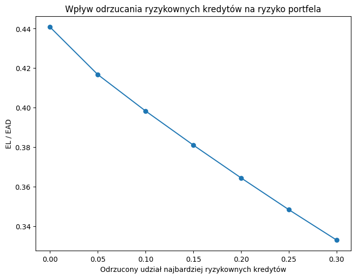

```python
symulacje = []

for odrzucany_proc in [0, 0.05, 0.10, 0.15, 0.20, 0.25, 0.30]:
    if odrzucany_proc == 0:
        portfel = wyniki.copy()
    else:
        prog = wyniki["EL"].quantile(1 - odrzucany_proc)
        portfel = wyniki[wyniki["EL"] <= prog].copy()

    symulacje.append({
        "odrzucony_proc_portfela": odrzucany_proc,
        "liczba_kredytow": len(portfel),
        "suma_EAD": portfel["EAD"].sum(),
        "suma_EL": portfel["EL"].sum(),
        "EL_do_EAD": portfel["EL"].sum() / portfel["EAD"].sum(),
        "srednie_PD": portfel["PD"].mean(),
        "srednie_LGD": portfel["LGD"].mean()
    })

symulacje = pd.DataFrame(symulacje)
display(symulacje)

plt.figure(figsize=(8, 6))
plt.plot(symulacje["odrzucony_proc_portfela"], symulacje["EL_do_EAD"], marker="o")
plt.xlabel("Odrzucony udział najbardziej ryzykownych kredytów")
plt.ylabel("EL / EAD")
plt.title("Wpływ odrzucania ryzykownych kredytów na ryzyko portfela")
plt.show()
```

Odrzucanie najbardziej ryzykownych kredytów prowadzi do wyraźnego spadku ryzyka portfela. Już przy odrzuceniu 10–15% kredytów o najwyższym Expected Loss relacja EL do EAD spada istotnie (z około 44% do około 38%), a przy 30% odrzuceń spada do około 33%.

Jednocześnie zmniejsza się zarówno średnie PD, jak i całkowita oczekiwana strata portfela. Warto jednak zauważyć, że redukcji ryzyka towarzyszy spadek liczby kredytów oraz wolumenu EAD, co oznacza potencjalny wpływ na przychody.

# Część G: Ważność zmiennych

Dla modeli drzewiastych można pokazać najważniejsze zmienne.

To pomaga w interpretacji modelu i wytłumaczeniu, które czynniki najbardziej wpływają na ryzyko.

|  | zmienna | waznosc |
| --- | --- | --- |
| 3 | int_rate | 998 |
| 6 | dti | 608 |
| 12 | revol_util | 558 |
| 14 | credit_history_months | 549 |
| 9 | open_acc | 498 |
| 18 | revol_bal_to_income | 494 |
| 5 | annual_inc | 488 |
| 11 | revol_bal | 463 |
| 13 | total_acc | 383 |
| 16 | loan_to_income | 334 |
| 4 | installment | 308 |
| 15 | installment_to_income | 305 |
| 0 | loan_amnt | 246 |
| 8 | inq_last_6mths | 215 |
| 17 | funded_to_income | 208 |
| 1 | funded_amnt | 192 |
| 2 | term_months | 171 |
| 10 | pub_rec | 160 |
| 73 | home_ownership_MORTGAGE | 151 |
| 7 | delinq_2yrs | 149 |
| 77 | home_ownership_RENT | 142 |
| 92 | purpose_small_business | 71 |
| 62 | emp_length_10+ years | 69 |
| 79 | verification_status_Source Verified | 63 |
| 20 | grade_B | 63 |
| 78 | verification_status_Not Verified | 62 |
| 71 | emp_length_< 1 year | 47 |
| 36 | sub_grade_C1 | 46 |
| 19 | grade_A | 44 |
| 21 | grade_C | 43 |

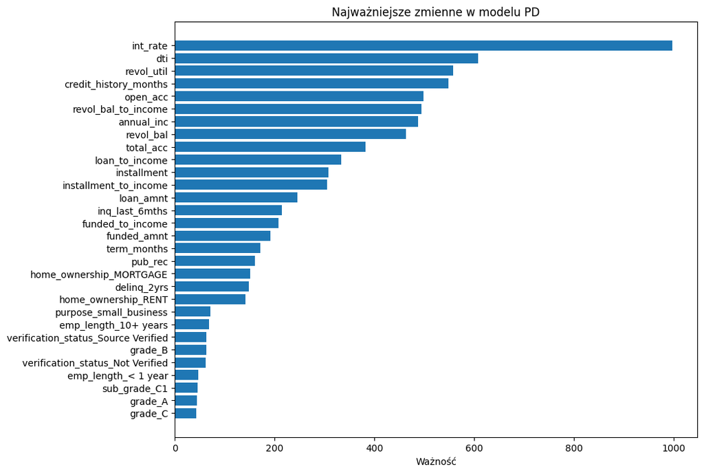

```python
def pobierz_nazwy_zmiennych_z_preprocessingu(preprocessing, zmienne_numeryczne, zmienne_kategoryczne):
    """
    Funkcja pobiera nazwy zmiennych po preprocessingu.
    Dla zmiennych numerycznych zostawia oryginalne nazwy, a dla zmiennych kategorycznych
    pobiera nazwy utworzone po kodowaniu one-hot.
    """
    nazwy_zmiennych = []

    nazwy_zmiennych.extend(zmienne_numeryczne)

    if len(zmienne_kategoryczne) > 0:
        pipeline_kategoryczny = preprocessing.named_transformers_["kategoryczne"]
        kodowanie = pipeline_kategoryczny.named_steps["kodowanie"]

        nazwy_kategoryczne = kodowanie.get_feature_names_out(
            zmienne_kategoryczne
        ).tolist()

        nazwy_zmiennych.extend(nazwy_kategoryczne)

    return nazwy_zmiennych


model_wewnetrzny = najlepszy_model_pd.named_steps["model"]

if hasattr(model_wewnetrzny, "feature_importances_"):
    nazwy_zmiennych_po_przetworzeniu = pobierz_nazwy_zmiennych_z_preprocessingu(
        najlepszy_model_pd.named_steps["preprocessing"],
        zmienne_numeryczne,
        zmienne_kategoryczne
    )

    waznosc_zmiennych = (
        pd.DataFrame({
            "zmienna": nazwy_zmiennych_po_przetworzeniu,
            "waznosc": model_wewnetrzny.feature_importances_
        })
        .sort_values("waznosc", ascending=False)
        .head(30)
    )

    display(waznosc_zmiennych)

    plt.figure(figsize=(10, 8))
    plt.barh(
        waznosc_zmiennych["zmienna"][::-1],
        waznosc_zmiennych["waznosc"][::-1]
    )
    plt.xlabel("Ważność")
    plt.title("Najważniejsze zmienne w modelu PD")
    plt.show()

else:
    print("Najlepszy model PD nie posiada atrybutu feature_importances_.")
```

Najważniejsze dla modelu PD są zmienne opisujące koszt kredytu, zadłużenie klienta oraz historię kredytową. Największy wpływ ma oprocentowanie, a dalej m.in. DTI, wykorzystanie limitu odnawialnego i długość historii kredytowej. Oznacza to, że model ocenia ryzyko głównie przez pryzmat obciążenia finansowego oraz wcześniejszej aktywności kredytowej klienta.

# Wnioski końcowe

1. Model PD osiąga umiarkowaną zdolność dyskryminacyjną (AUC ~0.72), co oznacza, że poprawnie rozróżnia klientów lepszych od gorszych, ale pozostawia przestrzeń do dalszej optymalizacji.
2. Model ma tendencję do zawyżania prawdopodobieństwa defaultu, co potwierdza analiza kalibracji – może to być celowe (konserwatywne podejście do ryzyka), ale wymaga ewentualnej kalibracji.
3. LGD jest bardzo wysokie (średnio ~93%), co oznacza, że w przypadku defaultu bank odzyskuje niewielką część należności – portfel jest silnie narażony na straty.
4. Model LGD ma niską zdolność wyjaśniania zmienności (niskie R²), co sugeruje, że strata po default jest trudna do przewidzenia na podstawie dostępnych zmiennych.
5. Największy wpływ na ryzyko mają zmienne finansowe klienta (oprocentowanie, DTI, wykorzystanie limitów), co jest spójne z praktyką kredytową.
6. Analiza segmentów pokazuje, że ryzyko rośnie wraz z pogorszeniem ratingu oraz jest wyższe dla niektórych celów kredytowych (np. small_business), co umożliwia segmentację portfela.
7. Symulacja strategii kredytowej pokazuje, że odrzucenie najbardziej ryzykownych klientów znacząco obniża poziom Expected Loss, co potwierdza praktyczną użyteczność modelu w zarządzaniu portfelem.